# Manuscript figures and tables

Glycemic traits, survival bias and Alzheimer’s disease: Mendelian randomization

Author

Dave Bridges and Katie Kittell

Published

November 17, 2026

Figures and tables for the manuscript (`Manuscripts/T2D_AD_MR/`). This notebook recomputes no MR estimates. It reads only committed CSVs, so every number traces to a commit.

**Conventions**

- **Chunk labels name content, not figure numbers.** Each figure is written to `figures/ms-<chunk label>-1.pdf` / `.png`, and figure numbers are assigned only in `Manuscripts/T2D_AD_MR/README.md`. Reordering figures, or reformatting for a journal, changes the README, not the files.
- **Source data.** Each figure chunk writes the data it plots to `results/manuscript/source_data/<chunk label>.csv`; panels within a chunk get a suffix.
- **Tables.** Written to `results/manuscript/tables/<name>.csv`.
- **Provenance.** The table in the next section is rebuilt on every render and saved as `results/manuscript/provenance.csv`. It records each input file, what produced it, the last commit that changed it, and whether it has uncommitted changes. For submission, render with `quarto render manuscript_figures.qmd -P strict:true`.

Derived from `t2d_ad_figures.qmd`, the colour, large-font version for talks. The estimators, filters and in-notebook calculations are the same, so the numbers match. These figures are greyscale for print: series are told apart by shape and line type, not colour. Three figures also add what the talk version left out (see the notes under each figure).

## Inputs and provenance

```r
library(dplyr)
library(tidyr)
library(readr)
library(ggplot2)
library(patchwork)
library(knitr)

res_dir <- "results/pipeline"
con_dir <- file.path(res_dir, "contrast")
ms_dir  <- "results/manuscript"
src_dir <- file.path(ms_dir, "source_data")
tab_dir <- file.path(ms_dir, "tables")
for (d in c(src_dir, tab_dir)) dir.create(d, recursive = TRUE, showWarnings = FALSE)

# Every file this notebook reads, and what wrote it. Pipeline history: results/pipeline/RUN_INFO.md.
inputs <- tibble::tribble(
  ~file,                                              ~produced_by,
  "pipeline/config.yml",                              "hand-edited pipeline settings; dataset definitions (data-sources table)",
  "results/pipeline/results.csv",                     "_targets.R `csv_results`; b_SH uncertainty added by pipeline/bsh_propagate_existing.R (7d9cad5)",
  "results/pipeline/instruments_classical.csv",       "_targets.R `csv_instruments_classical`",
  "ad_longevity_arm.csv",                             "exposure_survival_screen.qmd (Step 1 screen, OpenGWAS API)",
  "results/pipeline/contrast/results.csv",            "_targets.R `csv_contrast_results`; b_SH propagation (7d9cad5)",
  "results/pipeline/contrast/cluster_results.csv",    "_targets.R `csv_contrast_groups`; b_SH propagation (7d9cad5)",
  "results/pipeline/contrast/drug_target_results.csv","_targets.R `csv_cis_results`; b_SH propagation (7d9cad5)",
  "results/pipeline/contrast/instrument_outcome_data.csv", "_targets.R `csv_contrast_data`",
  "results/pipeline/contrast/step0_strength.csv",     "_targets.R `csv_contrast_strength` (outcome-blind Step 0, 38987ad)",
  "results/pipeline/contrast/xue_cluster_map.csv",    "_targets.R `csv_xue_cluster_map` (post-freeze LD map, 6814fd5)")

git <- function(...) suppressWarnings(tryCatch(system2("git", c(...), stdout = TRUE, stderr = FALSE),
                                               error = \(e) character()))
git_last <- function(f) {
  x <- git("log", "-1", shQuote("--format=%h %ad"), "--date=short", "--", shQuote(f))
  if (length(x)) x else "NOT COMMITTED"
}
git_dirty <- function(f) length(git("status", "--porcelain", "--", shQuote(f))) > 0
# Pipeline stamp (pipeline/R/provenance.R), if the file has one: step, commit, and whether the stamped
# md5 still matches the file. Files without one predate stamping (see results/pipeline/RUN_INFO.md).
stamp_of <- function(f) {
  s <- file.path(dirname(f), "stamps", paste0(basename(f), ".txt"))
  if (!file.exists(s)) return("none (see RUN_INFO.md)")
  kv <- sub("^[a-z_]+: ", "", setNames(readLines(s), sub(":.*", "", readLines(s))))
  sprintf("%s @ %s%s", kv[["step"]], kv[["git_commit"]],
          if (kv[["md5"]] == unname(tools::md5sum(f))) "" else " (FILE CHANGED SINCE STAMP)")
}

stopifnot("an input file is missing" = all(file.exists(inputs$file)))
provenance <- inputs |>
  mutate(md5         = substr(unname(tools::md5sum(file)), 1, 10),
         last_commit = unname(vapply(file, git_last, "")),
         uncommitted = unname(vapply(file, git_dirty, TRUE)),
         stamp       = unname(vapply(file, stamp_of, "")))
head_commit <- git("rev-parse", "--short", "HEAD")

if (any(provenance$uncommitted | provenance$last_commit == "NOT COMMITTED")) {
  msg <- paste("Inputs with uncommitted changes:",
               paste(provenance$file[provenance$uncommitted], collapse = ", "))
  if (isTRUE(params$strict)) stop(msg) else warning(msg)
}
write_csv(provenance |> mutate(rendered = as.character(Sys.Date()), rendered_at_commit = head_commit),
          file.path(ms_dir, "provenance.csv"))
kable(provenance, caption = sprintf("Rendered at commit %s.", head_commit))
```

Rendered at commit 60f2bf3.

| file | produced_by | md5 | last_commit | uncommitted | stamp |
| --- | --- | --- | --- | --- | --- |
| pipeline/config.yml | hand-edited pipeline settings; dataset definitions (data-sources table) | 9e9e1b60a0 | 60f2bf3 2026-11-17 | FALSE | none (see RUN_INFO.md) |
| results/pipeline/results.csv | _targets.R `csv_results`; b_SH uncertainty added by pipeline/bsh_propagate_existing.R (7d9cad5) | 3c77165e29 | 7d9cad5 2026-11-11 | FALSE | none (see RUN_INFO.md) |
| results/pipeline/instruments_classical.csv | _targets.R `csv_instruments_classical` | 37b835c661 | 42568d82 2026-10-08 | FALSE | none (see RUN_INFO.md) |
| ad_longevity_arm.csv | exposure_survival_screen.qmd (Step 1 screen, OpenGWAS API) | 7901949e22 | 64c7bbe6 2026-07-22 | FALSE | none (see RUN_INFO.md) |
| results/pipeline/contrast/results.csv | _targets.R `csv_contrast_results`; b_SH propagation (7d9cad5) | d6d45a90ba | 7d9cad5 2026-11-11 | FALSE | none (see RUN_INFO.md) |
| results/pipeline/contrast/cluster_results.csv | _targets.R `csv_contrast_groups`; b_SH propagation (7d9cad5) | 3df7f56f32 | 7d9cad5 2026-11-11 | FALSE | none (see RUN_INFO.md) |
| results/pipeline/contrast/drug_target_results.csv | _targets.R `csv_cis_results`; b_SH propagation (7d9cad5) | 9b98d98c43 | 7d9cad5 2026-11-11 | FALSE | none (see RUN_INFO.md) |
| results/pipeline/contrast/instrument_outcome_data.csv | _targets.R `csv_contrast_data` | 901995a518 | 6930e3e 2026-10-30 | FALSE | none (see RUN_INFO.md) |
| results/pipeline/contrast/step0_strength.csv | _targets.R `csv_contrast_strength` (outcome-blind Step 0, 38987ad) | a0622267de | 38987ad 2026-10-12 | FALSE | none (see RUN_INFO.md) |
| results/pipeline/contrast/xue_cluster_map.csv | _targets.R `csv_xue_cluster_map` (post-freeze LD map, 6814fd5) | b0e19ec0fa | 6814fd5 2026-10-29 | FALSE | none (see RUN_INFO.md) |

```r
# ---- read inputs (guess_max = Inf: the b_SH columns are NA for most rows and would be mis-typed) ----
rd  <- \(f) read_csv(f, show_col_types = FALSE, guess_max = Inf, name_repair = "unique_quiet")
res    <- rd(file.path(res_dir, "results.csv"))
inst   <- rd(file.path(res_dir, "instruments_classical.csv"))
con    <- rd(file.path(con_dir, "results.csv"))
con_cl <- rd(file.path(con_dir, "cluster_results.csv"))
con_dt <- rd(file.path(con_dir, "drug_target_results.csv"))
iod    <- rd(file.path(con_dir, "instrument_outcome_data.csv"))
step0  <- rd(file.path(con_dir, "step0_strength.csv"))
cfg    <- yaml::read_yaml("pipeline/config.yml")

# ---- settings: edit here -------------------------------------------------------------------
ad_outcome     <- "ad_bellenguez"                                 # pre-specified primary outcome
short <- c(bmi_ukb = "BMI", fatmass_ukb = "Fat mass", leanmass_pei = "Lean mass",
           ffm_ukb = "Fat-free mass", t2d_xue = "Type 2 diabetes",
           fg_dupuis = "Fasting glucose", glu2h_chen = "2 h glucose")
body_exposures <- c("t2d_xue", "bmi_ukb", "leanmass_pei")
glyc_exposures <- c("t2d_xue", "fg_dupuis", "glu2h_chen")
uv_methods <- c("IVW-MRE" = "IVW", "MRBEE" = "MRBEE", "Weighted median" = "Weighted median")
arm_labels <- c(raw = "Uncorrected", slopehunter = "SlopeHunter-corrected")
# AD outcomes for the fasting vs 2 h glucose, cluster and drug-target analyses (config `contrast: outcomes`)
con_outcomes <- tibble::tribble(
  ~outcome,            ~arm,          ~dataset,
  "ad_bellenguez",     "slopehunter", "Bellenguez 2022, SlopeHunter-corrected (primary)",
  "ad_kunkle",         "raw",         "Kunkle 2019, clinical",
  "ad_uffelmann_newc", "raw",         "Uffelmann 2026, new cohorts (replication)",
  "ad_uffelmann_cc",   "raw",         "Uffelmann 2026, clinical only")
rep_outcomes <- con_outcomes[c(1, 3), ]                           # primary + independent replication
comb_out <- "ad_uffelmann_all"; comb_arm <- "raw"
comb_lab <- "Uffelmann 2026, all cohorts (overlaps Bellenguez; uncorrected)"
con_methods <- c("IVW-MRE" = "IVW", "MRBEE" = "MRBEE")
set_labels  <- c(primary = "Suzuki 2024 instruments (pre-specified primary set)",
                 xue     = "Xue 2018 instruments (sensitivity set)")

# ---- palette (print-safe; maize darkened from the talk version) ---------------------------
# Greyscale for print: series are told apart by shape (and line type) as well as grey level, so
# the figures survive black-and-white printing. The colour versions for talks are in t2d_ad_figures.qmd.
ink <- "black"; dark <- "grey35"; mid <- "grey60"
method_cols  <- setNames(c(ink, dark, mid), uv_methods)
method_lty   <- setNames(c("solid", "dashed", "dotted"), uv_methods)
arm_cols     <- setNames(c(mid, ink), arm_labels)
arm_shapes   <- setNames(c(1, 16), arm_labels)                  # open = uncorrected, filled = corrected
con_cols     <- setNames(c(mid, ink), con_methods)
con_shapes   <- setNames(c(1, 16), con_methods)                 # open = IVW, filled = MRBEE
rep_cols     <- setNames(c(ink, mid), rep_outcomes$dataset)
rep_shapes   <- setNames(c(16, 17), rep_outcomes$dataset)       # circle = primary, triangle = replication
glu_cols     <- c(AD = ink, `Fasting glucose` = mid, `2 h glucose` = ink)
glu_shapes   <- c(AD = 16, `Fasting glucose` = 1, `2 h glucose` = 17)

theme_ms <- theme_bw(base_size = 10) +
  theme(legend.position = "bottom", panel.grid.minor = element_blank(),
        panel.grid.major.y = element_blank(), strip.background = element_blank(),
        strip.text = element_text(face = "bold"), plot.caption = element_text(hjust = 0, colour = "grey30"))

# ---- output helpers ------------------------------------------------------------------------
# Plotted data -> results/manuscript/source_data/<chunk label>[-suffix].csv
save_source <- function(d, suffix = NULL) {
  lab <- paste(c(knitr::opts_current$get("label"), suffix), collapse = "-")
  write_csv(d, file.path(src_dir, paste0(lab, ".csv")))
  invisible(d)
}
save_table <- function(d, name, caption = NULL) {
  write_csv(d, file.path(tab_dir, paste0(name, ".csv")))
  kable(d, caption = caption)
}
or_ci <- \(b, lo, hi) sprintf("%.2f (%.2f, %.2f)", exp(b), exp(lo), exp(hi))

uv_rows <- function(exposures, out, arms = c("raw", "slopehunter")) {
  res |>
    filter(exposure %in% exposures, outcome == out, arm %in% arms, method %in% names(uv_methods)) |>
    mutate(method_label   = factor(uv_methods[method], levels = uv_methods),
           arm_label      = factor(arm_labels[arm], levels = arm_labels),
           exposure_label = factor(short[exposure], levels = rev(short[exposures])))
}
forest_or <- function(dat, xlim, xlab = "Odds ratio for AD per unit higher exposure (95% CI)") {
  ggplot(dat, aes(x = exp(b), xmin = exp(ci_lo), xmax = exp(ci_hi), y = exposure_label,
                  colour = arm_label, shape = arm_label)) +
    geom_vline(xintercept = 1, linetype = "dashed", colour = "grey40") +
    geom_pointrange(position = position_dodge(width = 0.5), size = 0.35) +
    facet_wrap(~ method_label, nrow = 1) +
    scale_x_log10(limits = xlim) +
    scale_colour_manual(values = arm_cols, drop = FALSE) +
    scale_shape_manual(values = arm_shapes, drop = FALSE) +
    labs(x = xlab, y = NULL, colour = NULL, shape = NULL) +
    theme_ms
}
rep_forest <- function(d, xlab, caption = NULL) {
  ggplot(d, aes(x = exp(b), xmin = exp(b - 1.96 * se), xmax = exp(b + 1.96 * se), y = label,
                colour = dataset, shape = dataset)) +
    geom_vline(xintercept = 1, linetype = "dashed", colour = "grey40") +
    geom_pointrange(position = position_dodge(width = -0.6), size = 0.3) +
    scale_x_log10() +
    scale_colour_manual(values = rep_cols, breaks = rep_outcomes$dataset) +
    scale_shape_manual(values = rep_shapes, breaks = rep_outcomes$dataset) +
    labs(x = xlab, y = NULL, colour = NULL, shape = NULL, caption = caption) +
    theme_ms
}
```

## Data sources

Built from `pipeline/config.yml` → `datasets:`, the single place each GWAS is defined. Entries marked “TO CONFIRM” in the config are listed under Open items.

```r
`%||%` <- function(x, y) if (is.null(x)) y else x
role_of <- function(k) case_when(grepl("^ad_", k) ~ "Outcome: Alzheimer's disease",
                                 k == "lifespan" ~ "Selection axis (survival)",
                                 k %in% c("bmi_ukb", "fatmass_ukb", "ffm_ukb", "leanmass_pei") ~ "Exposure: body composition",
                                 TRUE ~ "Exposure: glycemic")
data_sources <- purrr::imap_dfr(cfg$datasets, \(d, k) tibble(
  key = k, Role = role_of(k), Dataset = d$label, Accession = d$id,
  `Obtained from` = c(opengwas_vcf = "OpenGWAS VCF", local_tsv = "local file", chrpos_tsv = "local file")[d$source],
  N = d$sample_size %||% NA_real_, Type = d$type,
  Cohorts = paste(d$cohorts, collapse = ", "), `Adjusted for` = d$adjusted_for %||% "none")) |>
  arrange(Role, key)
save_table(data_sources, "data_sources")
```

| key | Role | Dataset | Accession | Obtained from | N | Type | Cohorts | Adjusted for |
| --- | --- | --- | --- | --- | --- | --- | --- | --- |
| bmi_ukb | Exposure: body composition | BMI (UKB, MRC-IEU) | ukb-b-2303 | OpenGWAS VCF | 454884 | continuous | UKB | none |
| fatmass_ukb | Exposure: body composition | Whole-body fat mass (UKB, MRC-IEU) | ukb-b-19393 | OpenGWAS VCF | 454137 | continuous | UKB | none |
| ffm_ukb | Exposure: body composition | Whole-body fat-free mass (UKB, MRC-IEU) | ukb-b-13354 | OpenGWAS VCF | 454850 | continuous | UKB | none |
| leanmass_pei | Exposure: body composition | Appendicular lean mass (Pei 2020) | ebi-a-GCST90000025 | OpenGWAS VCF | 450243 | continuous | UKB | appendicular fat mass (Pei 2020 Methods) |
| fg_chen | Exposure: glycemic | Fasting glucose (Chen 2021, EUR) | ebi-a-GCST90002232 | OpenGWAS VCF | 200622 | continuous | MAGIC | BMI (Chen 2021 Methods) |
| fg_dupuis | Exposure: glycemic | Fasting glucose (Dupuis 2010) [primary FG] | ieu-b-4761 | OpenGWAS VCF | 46186 | continuous | MAGIC | none |
| fg_manning | Exposure: glycemic | Fasting glucose (Manning 2012) [original analysis] | ebi-a-GCST005186 | OpenGWAS VCF | 58074 | continuous | MAGIC | unclear: Manning 2012 fit models with and without BMI |
| glu2h_chen | Exposure: glycemic | 2-h glucose (Chen 2021, EUR) | ebi-a-GCST90002227 | OpenGWAS VCF | 63396 | continuous | MAGIC | BMI (Chen 2021 Methods) |
| t2d_suzuki_eur | Exposure: glycemic | Type 2 diabetes (Suzuki 2024, T2DGGI EUR) | T2DGGI-EUR | local file | NA | binary | DIAGRAM, UKB, MVP, FinnGen | none |
| t2d_xue | Exposure: glycemic | Type 2 diabetes (Xue 2018) | ebi-a-GCST006867 | OpenGWAS VCF | 655666 | binary | DIAGRAM, GERA, UKB | none |
| ad_bellenguez | Outcome: Alzheimer’s disease | AD: Bellenguez 2022 (proxy + clinical) | ebi-a-GCST90027158 | OpenGWAS VCF | 487511 | binary | EADB, UKB | none |
| ad_kunkle | Outcome: Alzheimer’s disease | AD: Kunkle 2019 IGAP (clinical only) | ieu-b-2 | local file | 63926 | binary | IGAP | none |
| ad_uffelmann_all | Outcome: Alzheimer’s disease | AD: Uffelmann 2026, all cohorts (clinical + proxy) | PGC-ALZ3-combined-EUR | local file | 354310 | binary | EADB, IGAP, UKB, MVP, FinnGen | none |
| ad_uffelmann_cc | Outcome: Alzheimer’s disease | AD: Uffelmann 2026, clinical cases only (all cohorts) | PGC-ALZ3-cc-EUR | local file | 307558 | binary | EADB, IGAP, UKB, MVP, FinnGen | none |
| ad_uffelmann_newc | Outcome: Alzheimer’s disease | AD: Uffelmann 2026, cohorts new to PGC-ALZ (independent of Bellenguez) | PGC-ALZ3-newc-EUR | local file | 103313 | binary | MVP, AllOfUs, Estonian, Regeneron, DBDS, HUSK, Lifelines | none |
| lifespan | Selection axis (survival) | Parental lifespan (Martingale residual; + = shorter life) | ebi-a-GCST006697 | local file | 389166 | continuous | UKB | none |

## Survival bias and its correction

### Both arms of the collider

Survival is a collider only if both the exposure and AD liability affect it. IVW only: the AD → lifespan arm comes from the Step 1 screen (`ad_longevity_arm.csv`), which has standard errors for IVW alone. Units differ by row, so read direction and whether the interval excludes zero.

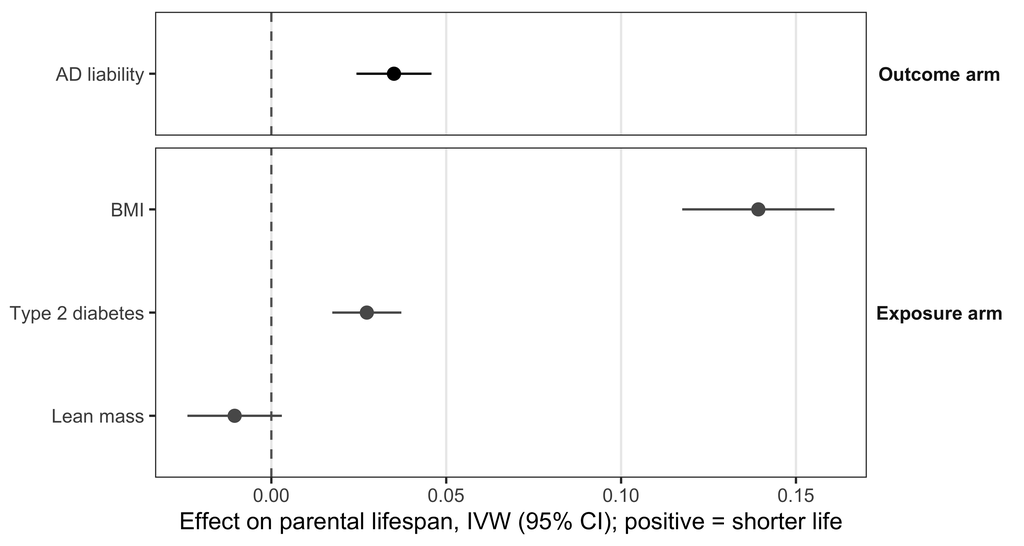

```r
ad_life <- read_csv("ad_longevity_arm.csv", show_col_types = FALSE) |>
  filter(grepl("Bellenguez", exposure), grepl("Martingale", survival)) |>
  transmute(label = "AD liability", arm = "Outcome arm", b, ci_lo = b - 1.96 * se, ci_hi = b + 1.96 * se, p, n_snp)
survival <- res |>
  filter(exposure %in% body_exposures, outcome == "lifespan", method == "IVW-MRE") |>
  transmute(label = short[exposure], arm = "Exposure arm", b, ci_lo, ci_hi, p, n_snp) |>
  bind_rows(ad_life) |>
  mutate(label = factor(label, levels = rev(c("AD liability", short[c("bmi_ukb", "t2d_xue", "leanmass_pei")]))),
         arm = factor(arm, levels = c("Outcome arm", "Exposure arm")))
save_source(survival)

ggplot(survival, aes(x = b, xmin = ci_lo, xmax = ci_hi, y = label, colour = arm)) +
  geom_vline(xintercept = 0, linetype = "dashed", colour = "grey40") +
  geom_pointrange(size = 0.4) +
  facet_grid(arm ~ ., scales = "free_y", space = "free_y") +
  scale_colour_manual(values = c("Outcome arm" = ink, "Exposure arm" = dark), guide = "none") +
  labs(x = "Effect on parental lifespan, IVW (95% CI); positive = shorter life", y = NULL) +
  theme_ms + theme(strip.text.y = element_text(angle = 0))
```

### Body composition and T2D → AD, before and after correction

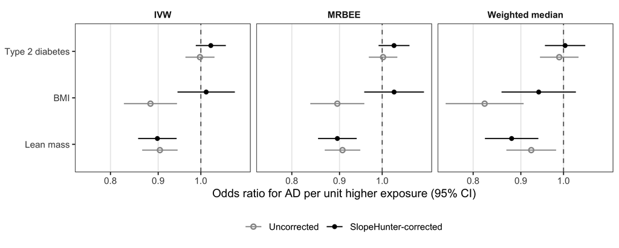

```r
body <- uv_rows(body_exposures, ad_outcome)
save_source(body |> select(exposure, outcome, arm, method, b, se, ci_lo, ci_hi, p, n_snp))
forest_or(body, range(exp(c(body$ci_lo, body$ci_hi))))
```

```r
kable(body |> arrange(desc(exposure_label), arm_label, method_label) |>
        transmute(Exposure = exposure_label, Arm = arm_label, Method = method,
                  `OR (95% CI)` = or_ci(b, ci_lo, ci_hi), p = signif(p, 2), SNPs = n_snp))
```

| Exposure | Arm | Method | OR (95% CI) | p | SNPs |
| --- | --- | --- | --- | --- | --- |
| Type 2 diabetes | Uncorrected | IVW-MRE | 1.00 (0.96, 1.03) | 9.1e-01 | 115 |
| Type 2 diabetes | Uncorrected | MRBEE | 1.00 (0.97, 1.04) | 9.0e-01 | 115 |
| Type 2 diabetes | Uncorrected | Weighted median | 0.99 (0.94, 1.04) | 6.6e-01 | 115 |
| Type 2 diabetes | SlopeHunter-corrected | IVW-MRE | 1.02 (0.99, 1.06) | 1.9e-01 | 109 |
| Type 2 diabetes | SlopeHunter-corrected | MRBEE | 1.03 (0.99, 1.07) | 1.3e-01 | 109 |
| Type 2 diabetes | SlopeHunter-corrected | Weighted median | 1.00 (0.96, 1.06) | 8.8e-01 | 109 |
| BMI | Uncorrected | IVW-MRE | 0.88 (0.83, 0.94) | 2.0e-04 | 414 |
| BMI | Uncorrected | MRBEE | 0.90 (0.84, 0.96) | 1.1e-03 | 414 |
| BMI | Uncorrected | Weighted median | 0.82 (0.75, 0.91) | 7.3e-05 | 414 |
| BMI | SlopeHunter-corrected | IVW-MRE | 1.01 (0.94, 1.09) | 7.2e-01 | 403 |
| BMI | SlopeHunter-corrected | MRBEE | 1.03 (0.96, 1.11) | 4.3e-01 | 403 |
| BMI | SlopeHunter-corrected | Weighted median | 0.94 (0.86, 1.03) | 1.9e-01 | 403 |
| Lean mass | Uncorrected | IVW-MRE | 0.90 (0.87, 0.94) | 6.0e-06 | 598 |
| Lean mass | Uncorrected | MRBEE | 0.91 (0.87, 0.95) | 1.2e-05 | 598 |
| Lean mass | Uncorrected | Weighted median | 0.92 (0.87, 0.98) | 1.1e-02 | 598 |
| Lean mass | SlopeHunter-corrected | IVW-MRE | 0.90 (0.86, 0.94) | 9.6e-06 | 531 |
| Lean mass | SlopeHunter-corrected | MRBEE | 0.90 (0.85, 0.94) | 5.5e-06 | 531 |
| Lean mass | SlopeHunter-corrected | Weighted median | 0.88 (0.82, 0.94) | 1.4e-04 | 531 |

## Glycemic traits → AD

Both arms are shown (the talk version showed the corrected arm only). SlopeHunter-corrected intervals include the uncertainty in b_SH, propagated per estimate (`pipeline/README.md`).

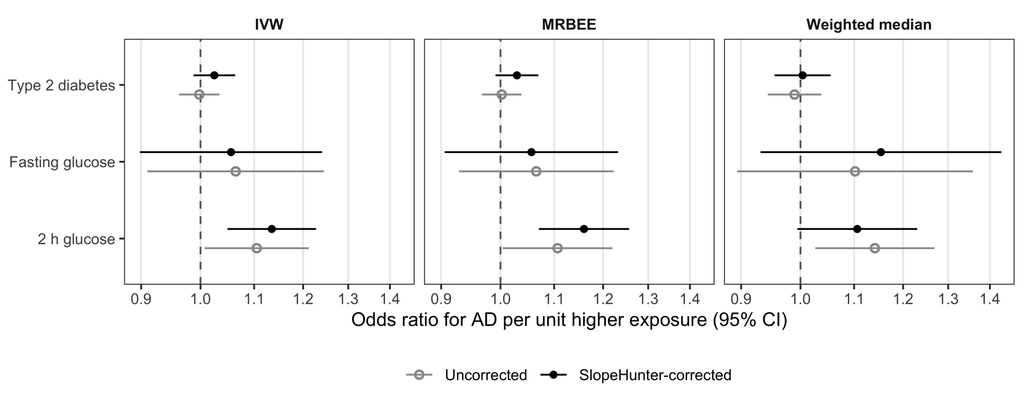

```r
glyc <- uv_rows(glyc_exposures, ad_outcome)
save_source(glyc |> select(exposure, outcome, arm, method, b, se, ci_lo, ci_hi, p, n_snp))
forest_or(glyc, range(exp(c(glyc$ci_lo, glyc$ci_hi))))
```

```r
kable(glyc |> arrange(desc(exposure_label), arm_label, method_label) |>
        transmute(Exposure = exposure_label, Arm = arm_label, Method = method,
                  `OR (95% CI)` = or_ci(b, ci_lo, ci_hi), p = signif(p, 2), SNPs = n_snp))
```

| Exposure | Arm | Method | OR (95% CI) | p | SNPs |
| --- | --- | --- | --- | --- | --- |
| Type 2 diabetes | Uncorrected | IVW-MRE | 1.00 (0.96, 1.03) | 0.91000 | 115 |
| Type 2 diabetes | Uncorrected | MRBEE | 1.00 (0.97, 1.04) | 0.90000 | 115 |
| Type 2 diabetes | Uncorrected | Weighted median | 0.99 (0.94, 1.04) | 0.66000 | 115 |
| Type 2 diabetes | SlopeHunter-corrected | IVW-MRE | 1.02 (0.99, 1.06) | 0.19000 | 109 |
| Type 2 diabetes | SlopeHunter-corrected | MRBEE | 1.03 (0.99, 1.07) | 0.13000 | 109 |
| Type 2 diabetes | SlopeHunter-corrected | Weighted median | 1.00 (0.96, 1.06) | 0.88000 | 109 |
| Fasting glucose | Uncorrected | IVW-MRE | 1.06 (0.91, 1.25) | 0.43000 | 11 |
| Fasting glucose | Uncorrected | MRBEE | 1.07 (0.93, 1.22) | 0.36000 | 11 |
| Fasting glucose | Uncorrected | Weighted median | 1.10 (0.89, 1.36) | 0.36000 | 11 |
| Fasting glucose | SlopeHunter-corrected | IVW-MRE | 1.06 (0.90, 1.24) | 0.51000 | 11 |
| Fasting glucose | SlopeHunter-corrected | MRBEE | 1.06 (0.91, 1.23) | 0.48000 | 11 |
| Fasting glucose | SlopeHunter-corrected | Weighted median | 1.15 (0.93, 1.43) | 0.19000 | 11 |
| 2 h glucose | Uncorrected | IVW-MRE | 1.10 (1.01, 1.21) | 0.03500 | 12 |
| 2 h glucose | Uncorrected | MRBEE | 1.11 (1.00, 1.22) | 0.04100 | 12 |
| 2 h glucose | Uncorrected | Weighted median | 1.14 (1.03, 1.27) | 0.01400 | 12 |
| 2 h glucose | SlopeHunter-corrected | IVW-MRE | 1.14 (1.05, 1.23) | 0.00160 | 12 |
| 2 h glucose | SlopeHunter-corrected | MRBEE | 1.16 (1.07, 1.26) | 0.00029 | 12 |
| 2 h glucose | SlopeHunter-corrected | Weighted median | 1.11 (0.99, 1.23) | 0.06300 | 12 |

## Fasting vs 2 h glucose

**Pre-specification.** The rule was fixed at Step 0, before any AD data were read: if the conditional F for 2 h glucose is at least 10, MVMR is primary; otherwise the contrast regression (by MRBEE) is primary, and MVMR is reported as underpowered. Conditional F was below 10 in every set (`step0_strength.csv`), so **the pre-specified primary estimate is the contrast regression on the Suzuki set**. The talk version plotted only MVMR on the Xue set. This figure shows both analyses on both sets, labelled. Scale: per mmol/L, which does not depend on the unconfirmed `sd_mmol` constants. Per-SD estimates are in the table.

- MVMR: $\hat\beta_{AD} = \theta_F\hat\beta_F + \theta_2\hat\beta_2$. The difference row is $\theta_2 - \theta_F$, with the full covariance.
- Contrast regression: $\hat\beta_{AD} = a(\hat\beta_2 - \hat\beta_F) + c\,\hat\beta_{T2D}$. $a > 0$ means the AD signal follows post-load-specific physiology (`pipeline/R/contrast_outcome.R`).

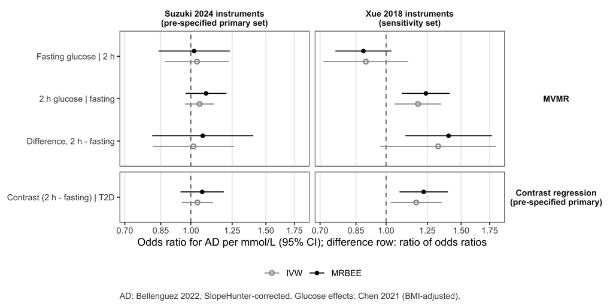

```r
term_labels <- c(fg = "Fasting glucose | 2 h", glu2h = "2 h glucose | fasting",
                 `glu2h - fg` = "Difference, 2 h - fasting", contrast = "Contrast (2 h - fasting) | T2D")
step_labels <- c(`1 MVMR` = "MVMR", `2 contrast regression` = "Contrast regression\n(pre-specified primary)")
fg2h <- con |>
  filter(outcome == ad_outcome, arm == "slopehunter", set %in% names(set_labels), scale == "per mmol/L",
         estimator %in% names(con_methods), term %in% names(term_labels)) |>
  mutate(ci_lo = b - 1.96 * se, ci_hi = b + 1.96 * se,
         set_label    = factor(set_labels[set], levels = set_labels),
         step_label   = factor(step_labels[step], levels = step_labels),
         term_label   = factor(term_labels[term], levels = rev(term_labels)),
         method_label = factor(con_methods[estimator], levels = con_methods))
save_source(fg2h |> select(set, outcome, arm, step, estimator, term, scale, b, se, ci_lo, ci_hi, p, n_snp))

ggplot(fg2h, aes(x = exp(b), xmin = exp(ci_lo), xmax = exp(ci_hi), y = term_label,
                 colour = method_label, shape = method_label)) +
  geom_vline(xintercept = 1, linetype = "dashed", colour = "grey40") +
  geom_pointrange(position = position_dodge(width = 0.5), size = 0.35) +
  facet_grid(step_label ~ set_label, scales = "free_y", space = "free_y",
             labeller = labeller(set_label = label_wrap_gen(30))) +
  scale_x_log10(breaks = c(0.7, 0.85, 1, 1.25, 1.5, 1.75)) +
  scale_colour_manual(values = con_cols) + scale_shape_manual(values = con_shapes) +
  labs(x = "Odds ratio for AD per mmol/L (95% CI); difference row: ratio of odds ratios", y = NULL,
       colour = NULL, shape = NULL,
       caption = "AD: Bellenguez 2022, SlopeHunter-corrected. Glucose effects: Chen 2021 (BMI-adjusted).") +
  theme_ms + theme(strip.text.y = element_text(angle = 0))
```

```r
fg2h_tab <- con |>
  filter(set %in% names(set_labels), estimator %in% names(con_methods), term %in% names(term_labels)) |>
  inner_join(bind_rows(con_outcomes, tibble(outcome = comb_out, arm = comb_arm, dataset = comb_lab)),
             by = c("outcome", "arm")) |>
  transmute(Instruments = set_labels[set], `AD dataset` = dataset, Analysis = step, Method = estimator,
            Term = term_labels[term], Scale = scale, b, se, `OR (95% CI)` = or_ci(b, b - 1.96 * se, b + 1.96 * se),
            p, p_bsh_cons, SNPs = n_snp) |>
  arrange(Instruments, `AD dataset`, Scale, Analysis, Method, Term)
save_table(fg2h_tab |> filter(Scale == "per mmol/L", `AD dataset` == con_outcomes$dataset[1]) |>
             select(-b, -se, -p_bsh_cons) |> mutate(p = signif(p, 2)), "fg_2h_primary_outcome")
```

| Instruments | AD dataset | Analysis | Method | Term | Scale | OR (95% CI) | p | SNPs |
| --- | --- | --- | --- | --- | --- | --- | --- | --- |
| Suzuki 2024 instruments (pre-specified primary set) | Bellenguez 2022, SlopeHunter-corrected (primary) | 1 MVMR | IVW-MRE | 2 h glucose \| fasting | per mmol/L | 1.05 (0.97, 1.14) | 0.2400 | 273 |
| Suzuki 2024 instruments (pre-specified primary set) | Bellenguez 2022, SlopeHunter-corrected (primary) | 1 MVMR | IVW-MRE | Difference, 2 h - fasting | per mmol/L | 1.01 (0.81, 1.26) | 0.9000 | 273 |
| Suzuki 2024 instruments (pre-specified primary set) | Bellenguez 2022, SlopeHunter-corrected (primary) | 1 MVMR | IVW-MRE | Fasting glucose \| 2 h | per mmol/L | 1.03 (0.87, 1.23) | 0.7000 | 273 |
| Suzuki 2024 instruments (pre-specified primary set) | Bellenguez 2022, SlopeHunter-corrected (primary) | 1 MVMR | MRBEE | 2 h glucose \| fasting | per mmol/L | 1.09 (0.97, 1.21) | 0.1500 | 273 |
| Suzuki 2024 instruments (pre-specified primary set) | Bellenguez 2022, SlopeHunter-corrected (primary) | 1 MVMR | MRBEE | Difference, 2 h - fasting | per mmol/L | 1.07 (0.81, 1.40) | 0.6400 | 273 |
| Suzuki 2024 instruments (pre-specified primary set) | Bellenguez 2022, SlopeHunter-corrected (primary) | 1 MVMR | MRBEE | Fasting glucose \| 2 h | per mmol/L | 1.02 (0.84, 1.23) | 0.8600 | 273 |
| Suzuki 2024 instruments (pre-specified primary set) | Bellenguez 2022, SlopeHunter-corrected (primary) | 2 contrast regression | IVW-MRE | Contrast (2 h - fasting) \| T2D | per mmol/L | 1.04 (0.95, 1.13) | 0.4100 | 273 |
| Suzuki 2024 instruments (pre-specified primary set) | Bellenguez 2022, SlopeHunter-corrected (primary) | 2 contrast regression | MRBEE | Contrast (2 h - fasting) \| T2D | per mmol/L | 1.06 (0.95, 1.20) | 0.3000 | 273 |
| Xue 2018 instruments (sensitivity set) | Bellenguez 2022, SlopeHunter-corrected (primary) | 1 MVMR | IVW-MRE | 2 h glucose \| fasting | per mmol/L | 1.19 (1.05, 1.35) | 0.0074 | 109 |
| Xue 2018 instruments (sensitivity set) | Bellenguez 2022, SlopeHunter-corrected (primary) | 1 MVMR | IVW-MRE | Difference, 2 h - fasting | per mmol/L | 1.32 (0.97, 1.81) | 0.0780 | 109 |
| Xue 2018 instruments (sensitivity set) | Bellenguez 2022, SlopeHunter-corrected (primary) | 1 MVMR | IVW-MRE | Fasting glucose \| 2 h | per mmol/L | 0.90 (0.71, 1.13) | 0.3500 | 109 |
| Xue 2018 instruments (sensitivity set) | Bellenguez 2022, SlopeHunter-corrected (primary) | 1 MVMR | MRBEE | 2 h glucose \| fasting | per mmol/L | 1.24 (1.09, 1.41) | 0.0011 | 109 |
| Xue 2018 instruments (sensitivity set) | Bellenguez 2022, SlopeHunter-corrected (primary) | 1 MVMR | MRBEE | Difference, 2 h - fasting | per mmol/L | 1.40 (1.11, 1.77) | 0.0046 | 109 |
| Xue 2018 instruments (sensitivity set) | Bellenguez 2022, SlopeHunter-corrected (primary) | 1 MVMR | MRBEE | Fasting glucose \| 2 h | per mmol/L | 0.88 (0.76, 1.03) | 0.1100 | 109 |
| Xue 2018 instruments (sensitivity set) | Bellenguez 2022, SlopeHunter-corrected (primary) | 2 contrast regression | IVW-MRE | Contrast (2 h - fasting) \| T2D | per mmol/L | 1.18 (1.03, 1.35) | 0.0200 | 109 |
| Xue 2018 instruments (sensitivity set) | Bellenguez 2022, SlopeHunter-corrected (primary) | 2 contrast regression | MRBEE | Contrast (2 h - fasting) \| T2D | per mmol/L | 1.23 (1.08, 1.40) | 0.0023 | 109 |

```r
write_csv(fg2h_tab, file.path(tab_dir, "fg_2h_all_outcomes.csv"))
```

### Replication

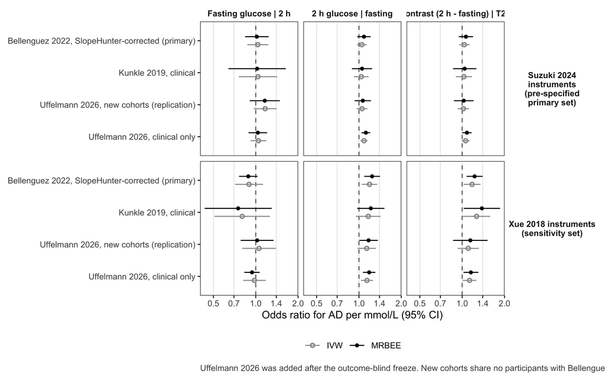

```r
fg2h_rep <- con |>
  filter(set %in% names(set_labels), scale == "per mmol/L", estimator %in% names(con_methods),
         term %in% c("fg", "glu2h", "contrast")) |>
  inner_join(con_outcomes, by = c("outcome", "arm")) |>
  mutate(ci_lo = b - 1.96 * se, ci_hi = b + 1.96 * se,
         set_label    = factor(set_labels[set], levels = set_labels),
         term_label   = factor(term_labels[term], levels = term_labels[c("fg", "glu2h", "contrast")]),
         method_label = factor(con_methods[estimator], levels = con_methods),
         dataset      = factor(dataset, levels = rev(con_outcomes$dataset)))
save_source(fg2h_rep |> select(set, outcome, arm, step, estimator, term, b, se, ci_lo, ci_hi, p, n_snp))

ggplot(fg2h_rep, aes(x = exp(b), xmin = exp(ci_lo), xmax = exp(ci_hi), y = dataset,
                     colour = method_label, shape = method_label)) +
  geom_vline(xintercept = 1, linetype = "dashed", colour = "grey40") +
  geom_pointrange(position = position_dodge(width = 0.5), size = 0.3) +
  facet_grid(set_label ~ term_label, labeller = labeller(set_label = label_wrap_gen(22))) +
  scale_x_log10(breaks = c(0.5, 0.7, 1, 1.4, 2)) +
  scale_colour_manual(values = con_cols) + scale_shape_manual(values = con_shapes) +
  labs(x = "Odds ratio for AD per mmol/L (95% CI)", y = NULL, colour = NULL, shape = NULL,
       caption = "Uffelmann 2026 was added after the outcome-blind freeze. New cohorts share no participants with Bellenguez; MVP is also in the Suzuki T2D GWAS.") +
  theme_ms + theme(strip.text.y = element_text(angle = 0))
```

### Validation: separability and the added-variable plot

For each instrument set: left, each variant’s fasting vs 2 h glucose effect (identification needs the mix to vary); right, the Frisch–Waugh–Lovell added-variable plot, whose slope is exactly the IVW estimate of $\theta_2$.

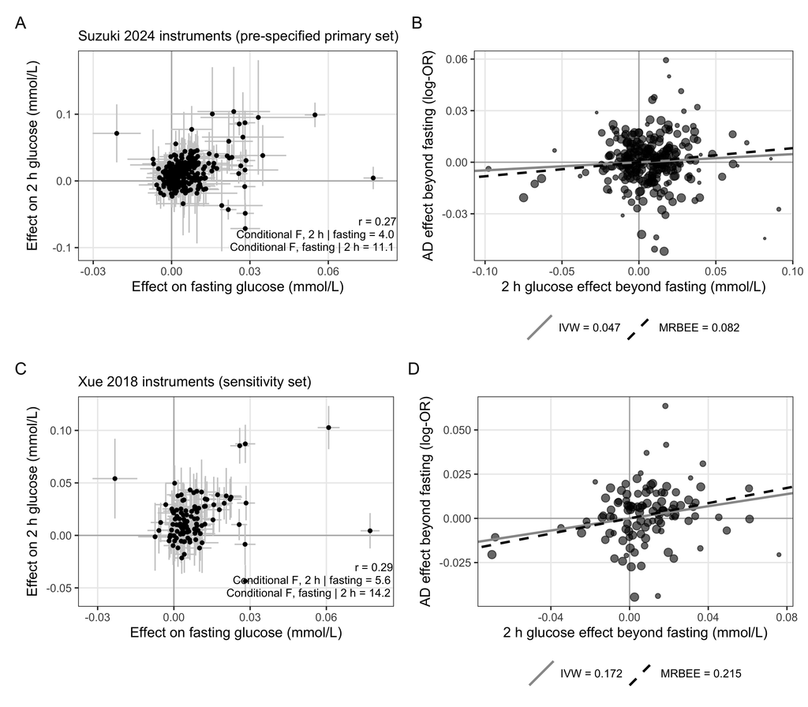

```r
validation_panels <- function(s) {
  val <- iod |> filter(set == s, outcome == ad_outcome, arm == "slopehunter") |> mutate(w = 1 / se_y^2)
  st  <- step0 |> filter(set == s)
  val <- val |> mutate(resid_y  = resid(lm(beta_y ~ 0 + beta_fg, weights = w)),
                       resid_2h = resid(lm(beta_2h ~ 0 + beta_fg, weights = w)))
  fwl <- coef(lm(resid_y ~ 0 + resid_2h, data = val, weights = w))[[1]]
  mv  <- coef(lm(beta_y ~ 0 + beta_fg + beta_2h, data = val, weights = w))[["beta_2h"]]
  stopifnot(abs(fwl - mv) < 1e-10)   # the added-variable slope IS the MVMR IVW estimate
  mrbee <- fg2h |> filter(set == s, step == "1 MVMR", estimator == "MRBEE", term == "glu2h") |> pull(b)
  save_source(val |> select(set, SNP, beta_fg, se_fg, beta_2h, se_2h, beta_y, se_y, w, resid_2h, resid_y), s)

  p1 <- ggplot(val, aes(beta_fg, beta_2h)) +
    geom_hline(yintercept = 0, colour = "grey70") + geom_vline(xintercept = 0, colour = "grey70") +
    geom_errorbar(aes(ymin = beta_2h - 1.96 * se_2h, ymax = beta_2h + 1.96 * se_2h), colour = "grey80", width = 0) +
    geom_errorbar(aes(xmin = beta_fg - 1.96 * se_fg, xmax = beta_fg + 1.96 * se_fg), colour = "grey80",
                  width = 0, orientation = "y") +
    geom_point(colour = ink, size = 1) +
    annotate("text", x = Inf, y = -Inf, hjust = 1.02, vjust = -0.3, size = 2.8, lineheight = 0.95,
             label = sprintf("r = %.2f\nConditional F, 2 h | fasting = %.1f\nConditional F, fasting | 2 h = %.1f",
                             cor(val$beta_fg, val$beta_2h), st$cond_F_2h, st$cond_F_fg)) +
    labs(x = "Effect on fasting glucose (mmol/L)", y = "Effect on 2 h glucose (mmol/L)",
         subtitle = set_labels[[s]]) +
    theme_ms + theme(panel.grid.major.y = element_line())
  p2 <- ggplot(val, aes(resid_2h, resid_y)) +
    geom_hline(yintercept = 0, colour = "grey70") + geom_vline(xintercept = 0, colour = "grey70") +
    geom_point(aes(size = w), colour = ink, alpha = 0.6, show.legend = FALSE) +
    geom_abline(aes(slope = fwl, intercept = 0, colour = "IVW"), linewidth = 0.8) +
    geom_abline(aes(slope = mrbee, intercept = 0, colour = "MRBEE"), linewidth = 0.8, linetype = "dashed") +
    scale_size_area(max_size = 2.5) +
    scale_colour_manual(values = c(IVW = mid, MRBEE = ink),
                        labels = c(IVW = sprintf("IVW = %.3f", fwl), MRBEE = sprintf("MRBEE = %.3f", mrbee))) +
    labs(x = "2 h glucose effect beyond fasting (mmol/L)", y = "AD effect beyond fasting (log-OR)", colour = NULL) +
    theme_ms + theme(panel.grid.major.y = element_line())
  p1 + p2
}
validation_panels("primary") / validation_panels("xue") + plot_annotation(tag_levels = "A")
```

## T2D liability → AD by mechanistic cluster

Suzuki 2024 instruments split by the paper’s clusters (frozen before any AD data were read). Left: AD per unit log-odds of T2D carried by the cluster. Right: the same variants’ effect on fasting and 2 h glucose. The glucose slopes are computed here from `instrument_outcome_data.csv`: IVW through the origin on the T2D effect, residual scale floored at 1, as in the pipeline’s `wls_mre()`. The liver/lipid cluster (2 variants) and “other (small)” are in the table only.

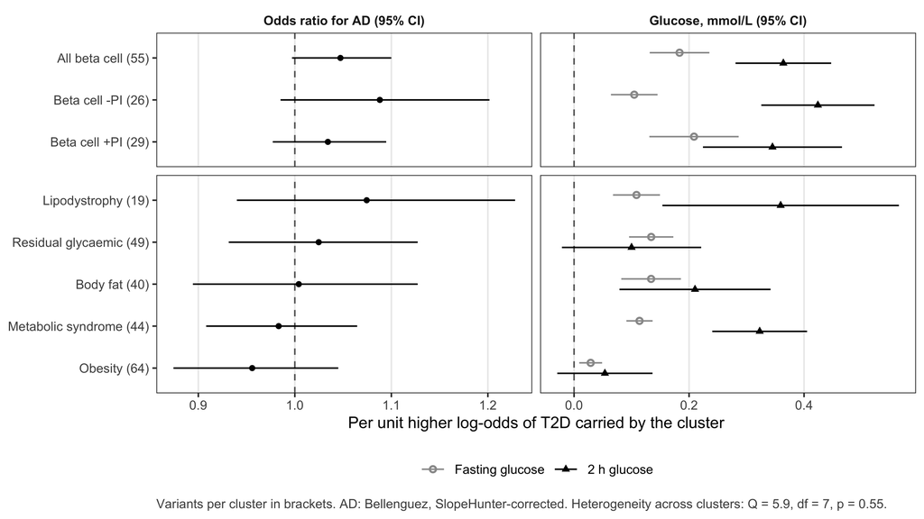

```r
beta_levels <- c("All beta cell", "Beta cell -PI", "Beta cell +PI")
cl_pick <- function(d) d |>
  filter(set == "primary",
         model == "T2D effect x cluster" | (model == "T2D effect x beta-cell" & grepl("^Beta", group))) |>
  mutate(group = if_else(model == "T2D effect x beta-cell", "All beta cell", group))
cl <- cl_pick(con_cl) |>
  filter(outcome == ad_outcome, arm == "slopehunter") |>
  mutate(ci_lo = b - 1.96 * se, ci_hi = b + 1.96 * se,
         kind = if_else(group %in% beta_levels, "Beta-cell clusters", "Other clusters")) |>
  arrange(kind != "Beta-cell clusters", match(group, beta_levels), desc(b)) |>
  mutate(label = sprintf("%s (%d)", group, n_snp), label = factor(label, levels = rev(label)))
cl_het <- con_cl |>
  filter(set == "primary", outcome == ad_outcome, arm == "slopehunter", model == "T2D effect x cluster") |>
  distinct(het_Q, het_df, het_p)

ivw_slope <- function(y, se, x) {
  f <- summary(lm(y ~ 0 + x, weights = 1 / se^2))
  tibble(b = f$coefficients[1, 1], se = f$coefficients[1, 2] / f$sigma * max(1, f$sigma))
}
con_snps <- iod |> filter(set == "primary", outcome == ad_outcome, arm == "slopehunter")
cl_glu <- bind_rows(con_snps, con_snps |> filter(grepl("^Beta cell", cluster)) |> mutate(cluster = "All beta cell")) |>
  group_by(group = cluster) |>
  reframe(bind_rows(`Fasting glucose` = ivw_slope(beta_fg, se_fg, beta_t2d),
                    `2 h glucose` = ivw_slope(beta_2h, se_2h, beta_t2d), .id = "series")) |>
  mutate(ci_lo = b - 1.96 * se, ci_hi = b + 1.96 * se)
cl_both <- cl |>
  transmute(group, series = "AD", b = exp(b), ci_lo = exp(ci_lo), ci_hi = exp(ci_hi), panel = "AD risk") |>
  bind_rows(cl_glu |> mutate(panel = "Glucose") |> select(group, series, b, ci_lo, ci_hi, panel)) |>
  inner_join(cl |> select(group, label, kind), by = "group") |>
  filter(!group %in% c("other (small)", "Liver/lipid metabolism")) |>
  mutate(panel = factor(panel, levels = c("AD risk", "Glucose")))
save_source(cl_both)

ggplot(cl_both, aes(x = b, xmin = ci_lo, xmax = ci_hi, y = label, colour = series, shape = series)) +
  geom_vline(data = data.frame(panel = factor(c("AD risk", "Glucose"), levels = c("AD risk", "Glucose")), x = c(1, 0)),
             aes(xintercept = x), linetype = "dashed", colour = "grey40") +
  geom_pointrange(position = position_dodge(width = 0.5), size = 0.3) +
  facet_grid(kind ~ panel, scales = "free", space = "free_y",
             labeller = labeller(panel = c(`AD risk` = "Odds ratio for AD (95% CI)",
                                           Glucose = "Glucose, mmol/L (95% CI)"))) +
  scale_colour_manual(values = glu_cols, breaks = c("Fasting glucose", "2 h glucose")) +
  scale_shape_manual(values = glu_shapes, breaks = c("Fasting glucose", "2 h glucose")) +
  labs(x = "Per unit higher log-odds of T2D carried by the cluster", y = NULL, colour = NULL, shape = NULL,
       caption = sprintf("Variants per cluster in brackets. AD: Bellenguez, SlopeHunter-corrected. Heterogeneity across clusters: Q = %.1f, df = %d, p = %.2f.",
                         cl_het$het_Q, cl_het$het_df, cl_het$het_p)) +
  theme_ms + theme(strip.text.y = element_blank())
```

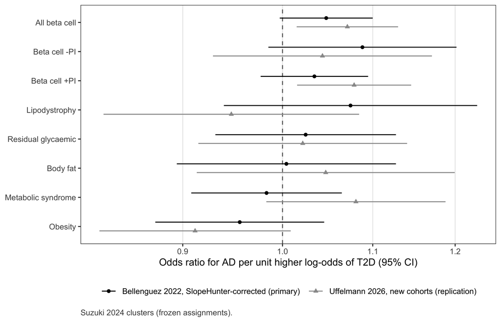

```r
cl_rep <- cl_pick(con_cl) |>
  inner_join(rep_outcomes, by = c("outcome", "arm")) |>
  filter(!group %in% c("other (small)", "Liver/lipid metabolism")) |>
  mutate(label = factor(group, levels = rev(unique(cl$group))), dataset = factor(dataset, levels = rep_outcomes$dataset))
save_source(cl_rep |> select(set, outcome, arm, model, group, b, se, p, n_snp))
rep_forest(cl_rep, "Odds ratio for AD per unit higher log-odds of T2D (95% CI)", "Suzuki 2024 clusters (frozen assignments).")
```

```r
cl_tab <- cl_pick(con_cl) |>
  inner_join(bind_rows(con_outcomes, tibble(outcome = comb_out, arm = comb_arm, dataset = comb_lab)),
             by = c("outcome", "arm")) |>
  transmute(Cluster = group, `AD dataset` = dataset, SNPs = n_snp, b, se,
            `OR (95% CI)` = or_ci(b, b - 1.96 * se, b + 1.96 * se), p, het_Q, het_df, het_p)
write_csv(cl_tab, file.path(tab_dir, "cluster_results.csv"))
cl_glu |>
  mutate(est = sprintf("%.2f (%.2f, %.2f)", b, ci_lo, ci_hi)) |>
  select(Cluster = group, series, est) |>
  pivot_wider(names_from = series, values_from = est) |>
  inner_join(cl |> transmute(Cluster = group, SNPs = n_snp, `AD OR (95% CI)` = or_ci(b, ci_lo, ci_hi), p = signif(p, 2)),
             by = "Cluster") |>
  arrange(match(Cluster, cl$group)) |>
  select(Cluster, SNPs, `AD OR (95% CI)`, p, `Fasting glucose`, `2 h glucose`) |>
  save_table("cluster_primary_outcome", "Glucose columns: mmol/L per unit higher log-odds of T2D (95% CI).")
```

Glucose columns: mmol/L per unit higher log-odds of T2D (95% CI).

| Cluster | SNPs | AD OR (95% CI) | p | Fasting glucose | 2 h glucose |
| --- | --- | --- | --- | --- | --- |
| All beta cell | 55 | 1.05 (1.00, 1.10) | 0.065 | 0.18 (0.13, 0.24) | 0.36 (0.28, 0.45) |
| Beta cell -PI | 26 | 1.09 (0.99, 1.20) | 0.096 | 0.10 (0.06, 0.15) | 0.42 (0.33, 0.52) |
| Beta cell +PI | 29 | 1.03 (0.98, 1.09) | 0.250 | 0.21 (0.13, 0.29) | 0.35 (0.22, 0.47) |
| Lipodystrophy | 19 | 1.07 (0.94, 1.23) | 0.290 | 0.11 (0.07, 0.15) | 0.36 (0.15, 0.57) |
| Residual glycaemic | 49 | 1.02 (0.93, 1.13) | 0.620 | 0.13 (0.10, 0.17) | 0.10 (-0.02, 0.22) |
| Body fat | 40 | 1.00 (0.89, 1.13) | 0.940 | 0.13 (0.08, 0.19) | 0.21 (0.08, 0.34) |
| Metabolic syndrome | 44 | 0.98 (0.91, 1.06) | 0.680 | 0.11 (0.09, 0.14) | 0.32 (0.24, 0.41) |
| Obesity | 64 | 0.96 (0.87, 1.04) | 0.320 | 0.03 (0.01, 0.05) | 0.05 (-0.03, 0.14) |

## Drug targets

Variants within 100 kb of each glucose-lowering drug target (T2D-associated at p < 10⁻⁴; targets of drugs at phase 2 or later for T2D, frozen Open Targets snapshot). Classes with fewer than 3 variants are in the table only.

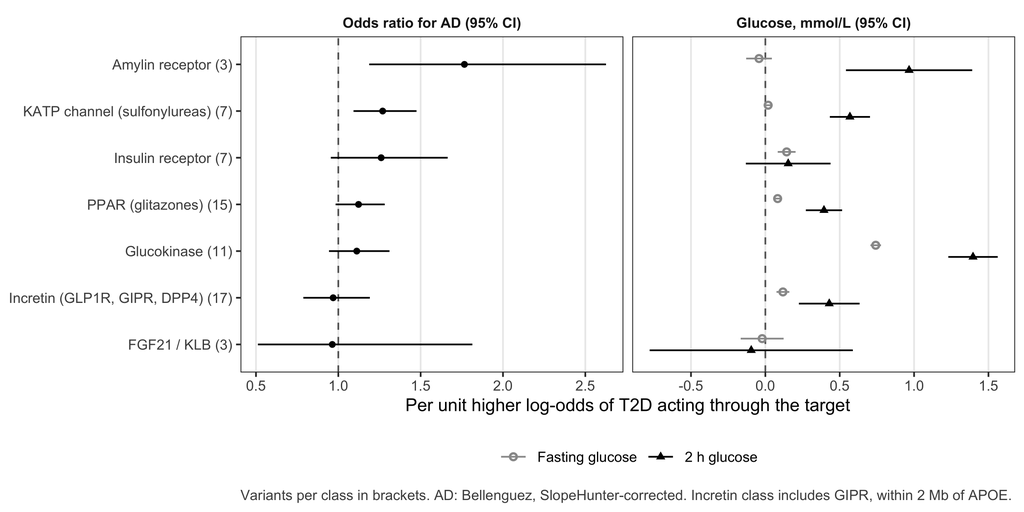

```r
class_labels <- c(katp_secretagogue = "KATP channel (sulfonylureas)", amylin = "Amylin receptor",
                  pparg_sensitizer = "PPAR (glitazones)", glucokinase = "Glucokinase",
                  insulin_receptor = "Insulin receptor", incretin = "Incretin (GLP1R, GIPR, DPP4)",
                  fgf21_klb = "FGF21 / KLB", sglt = "SGLT", glucagon_receptor = "Glucagon receptor")
dt <- con_dt |>
  filter(set == "primary", level == "class") |>
  mutate(ci_lo = b - 1.96 * se, ci_hi = b + 1.96 * se, class = coalesce(class_labels[target], target))
dt_order <- dt |> filter(outcome == ad_outcome, arm == "slopehunter", trait == "AD (log-OR)") |>
  arrange(b) |> mutate(label = sprintf("%s (%d)", class, n_snp))
dt_plot <- dt |>
  filter(outcome == ad_outcome, arm == "slopehunter", n_snp >= 3) |>
  inner_join(dt_order |> select(target, label), by = "target") |>
  mutate(label = factor(label, levels = dt_order$label),
         panel = factor(if_else(trait == "AD (log-OR)", "AD risk", "Glucose"), levels = c("AD risk", "Glucose")),
         series = case_when(trait == "AD (log-OR)" ~ "AD", grepl("^fasting", trait) ~ "Fasting glucose",
                            TRUE ~ "2 h glucose"),
         across(c(b, ci_lo, ci_hi), \(v) if_else(panel == "AD risk", exp(v), v)))
save_source(dt_plot |> select(target, class, outcome, arm, trait, series, b, ci_lo, ci_hi, p, n_snp))

ggplot(dt_plot, aes(x = b, xmin = ci_lo, xmax = ci_hi, y = label, colour = series, shape = series)) +
  geom_vline(data = data.frame(panel = factor(c("AD risk", "Glucose"), levels = c("AD risk", "Glucose")), x = c(1, 0)),
             aes(xintercept = x), linetype = "dashed", colour = "grey40") +
  geom_pointrange(position = position_dodge(width = 0.5), size = 0.3) +
  facet_wrap(~ panel, scales = "free_x",
             labeller = as_labeller(c(`AD risk` = "Odds ratio for AD (95% CI)", Glucose = "Glucose, mmol/L (95% CI)"))) +
  scale_colour_manual(values = glu_cols, breaks = c("Fasting glucose", "2 h glucose")) +
  scale_shape_manual(values = glu_shapes, breaks = c("Fasting glucose", "2 h glucose")) +
  labs(x = "Per unit higher log-odds of T2D acting through the target", y = NULL, colour = NULL, shape = NULL,
       caption = "Variants per class in brackets. AD: Bellenguez, SlopeHunter-corrected. Incretin class includes GIPR, within 2 Mb of APOE.") +
  theme_ms
```

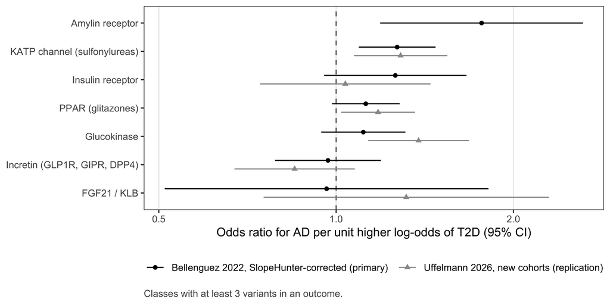

```r
dt_rep <- dt |>
  filter(trait == "AD (log-OR)", n_snp >= 3, target %in% dt_plot$target) |>
  inner_join(rep_outcomes, by = c("outcome", "arm")) |>
  mutate(label = factor(class, levels = unique(dt_order$class)), dataset = factor(dataset, levels = rep_outcomes$dataset))
save_source(dt_rep |> select(target, class, outcome, arm, b, se, p, n_snp))
rep_forest(dt_rep, "Odds ratio for AD per unit higher log-odds of T2D (95% CI)", "Classes with at least 3 variants in an outcome.")
```

```r
dt |>
  filter(trait == "AD (log-OR)") |>
  inner_join(bind_rows(con_outcomes, tibble(outcome = comb_out, arm = comb_arm, dataset = comb_lab)),
             by = c("outcome", "arm")) |>
  transmute(Class = class, `AD dataset` = dataset, SNPs = n_snp, b, se,
            `OR (95% CI)` = or_ci(b, ci_lo, ci_hi), p = signif(p, 2)) |>
  arrange(Class, `AD dataset`) |>
  save_table("drug_target_results")
```

| Class | AD dataset | SNPs | b | se | OR (95% CI) | p |
| --- | --- | --- | --- | --- | --- | --- |
| Amylin receptor | Bellenguez 2022, SlopeHunter-corrected (primary) | 3 | 0.5686522 | 0.2023764 | 1.77 (1.19, 2.63) | 0.00500 |
| Amylin receptor | Kunkle 2019, clinical | 3 | 0.3853321 | 0.3512649 | 1.47 (0.74, 2.93) | 0.27000 |
| Amylin receptor | Uffelmann 2026, all cohorts (overlaps Bellenguez; uncorrected) | 2 | 0.2979788 | 0.1474220 | 1.35 (1.01, 1.80) | 0.04300 |
| Amylin receptor | Uffelmann 2026, clinical only | 2 | 0.2922288 | 0.1602103 | 1.34 (0.98, 1.83) | 0.06800 |
| FGF21 / KLB | Bellenguez 2022, SlopeHunter-corrected (primary) | 3 | -0.0371919 | 0.3228636 | 0.96 (0.51, 1.81) | 0.91000 |
| FGF21 / KLB | Kunkle 2019, clinical | 4 | 0.2778672 | 0.4260450 | 1.32 (0.57, 3.04) | 0.51000 |
| FGF21 / KLB | Uffelmann 2026, all cohorts (overlaps Bellenguez; uncorrected) | 4 | 0.0326851 | 0.1566264 | 1.03 (0.76, 1.40) | 0.83000 |
| FGF21 / KLB | Uffelmann 2026, clinical only | 4 | 0.1474294 | 0.1696789 | 1.16 (0.83, 1.62) | 0.38000 |
| FGF21 / KLB | Uffelmann 2026, new cohorts (replication) | 4 | 0.2741063 | 0.2844810 | 1.32 (0.75, 2.30) | 0.34000 |
| Glucokinase | Bellenguez 2022, SlopeHunter-corrected (primary) | 11 | 0.1062256 | 0.0839450 | 1.11 (0.94, 1.31) | 0.21000 |
| Glucokinase | Kunkle 2019, clinical | 9 | -0.0997108 | 0.1508285 | 0.91 (0.67, 1.22) | 0.51000 |
| Glucokinase | Uffelmann 2026, all cohorts (overlaps Bellenguez; uncorrected) | 8 | 0.0541697 | 0.0573101 | 1.06 (0.94, 1.18) | 0.34000 |
| Glucokinase | Uffelmann 2026, clinical only | 8 | 0.0879500 | 0.0615532 | 1.09 (0.97, 1.23) | 0.15000 |
| Glucokinase | Uffelmann 2026, new cohorts (replication) | 8 | 0.3223015 | 0.1005042 | 1.38 (1.13, 1.68) | 0.00130 |
| Incretin (GLP1R, GIPR, DPP4) | Bellenguez 2022, SlopeHunter-corrected (primary) | 17 | -0.0317378 | 0.1056039 | 0.97 (0.79, 1.19) | 0.76000 |
| Incretin (GLP1R, GIPR, DPP4) | Kunkle 2019, clinical | 15 | -0.4340734 | 0.1843458 | 0.65 (0.45, 0.93) | 0.01900 |
| Incretin (GLP1R, GIPR, DPP4) | Uffelmann 2026, all cohorts (overlaps Bellenguez; uncorrected) | 15 | -0.1198694 | 0.0661401 | 0.89 (0.78, 1.01) | 0.07000 |
| Incretin (GLP1R, GIPR, DPP4) | Uffelmann 2026, clinical only | 15 | -0.1202004 | 0.0717272 | 0.89 (0.77, 1.02) | 0.09400 |
| Incretin (GLP1R, GIPR, DPP4) | Uffelmann 2026, new cohorts (replication) | 14 | -0.1622063 | 0.1200238 | 0.85 (0.67, 1.08) | 0.18000 |
| Insulin receptor | Bellenguez 2022, SlopeHunter-corrected (primary) | 7 | 0.2314231 | 0.1418385 | 1.26 (0.95, 1.66) | 0.10000 |
| Insulin receptor | Kunkle 2019, clinical | 6 | 0.7445908 | 0.2478740 | 2.11 (1.30, 3.42) | 0.00270 |
| Insulin receptor | Uffelmann 2026, all cohorts (overlaps Bellenguez; uncorrected) | 7 | 0.2471851 | 0.0905377 | 1.28 (1.07, 1.53) | 0.00630 |
| Insulin receptor | Uffelmann 2026, clinical only | 6 | 0.3663937 | 0.0996298 | 1.44 (1.19, 1.75) | 0.00024 |
| Insulin receptor | Uffelmann 2026, new cohorts (replication) | 5 | 0.0359439 | 0.1699604 | 1.04 (0.74, 1.45) | 0.83000 |
| KATP channel (sulfonylureas) | Bellenguez 2022, SlopeHunter-corrected (primary) | 7 | 0.2384774 | 0.0766373 | 1.27 (1.09, 1.48) | 0.00190 |
| KATP channel (sulfonylureas) | Kunkle 2019, clinical | 5 | 0.0051327 | 0.1691282 | 1.01 (0.72, 1.40) | 0.98000 |
| KATP channel (sulfonylureas) | Uffelmann 2026, all cohorts (overlaps Bellenguez; uncorrected) | 5 | 0.0808118 | 0.0515025 | 1.08 (0.98, 1.20) | 0.12000 |
| KATP channel (sulfonylureas) | Uffelmann 2026, clinical only | 5 | 0.1007470 | 0.0560150 | 1.11 (0.99, 1.23) | 0.07200 |
| KATP channel (sulfonylureas) | Uffelmann 2026, new cohorts (replication) | 5 | 0.2522133 | 0.0932117 | 1.29 (1.07, 1.54) | 0.00680 |
| PPAR (glitazones) | Bellenguez 2022, SlopeHunter-corrected (primary) | 15 | 0.1158739 | 0.0675787 | 1.12 (0.98, 1.28) | 0.08600 |
| PPAR (glitazones) | Kunkle 2019, clinical | 14 | 0.1845969 | 0.1156211 | 1.20 (0.96, 1.51) | 0.11000 |
| PPAR (glitazones) | Uffelmann 2026, all cohorts (overlaps Bellenguez; uncorrected) | 15 | 0.0928355 | 0.0413565 | 1.10 (1.01, 1.19) | 0.02500 |
| PPAR (glitazones) | Uffelmann 2026, clinical only | 15 | 0.1194909 | 0.0447029 | 1.13 (1.03, 1.23) | 0.00750 |
| PPAR (glitazones) | Uffelmann 2026, new cohorts (replication) | 13 | 0.1639771 | 0.0736092 | 1.18 (1.02, 1.36) | 0.02600 |
| SGLT | Bellenguez 2022, SlopeHunter-corrected (primary) | 2 | 0.1185062 | 0.3760557 | 1.13 (0.54, 2.35) | 0.75000 |
| SGLT | Kunkle 2019, clinical | 2 | 0.3568572 | 0.6409689 | 1.43 (0.41, 5.02) | 0.58000 |
| SGLT | Uffelmann 2026, all cohorts (overlaps Bellenguez; uncorrected) | 2 | -0.1899631 | 0.2291017 | 0.83 (0.53, 1.30) | 0.41000 |
| SGLT | Uffelmann 2026, clinical only | 2 | -0.2809874 | 0.2501151 | 0.76 (0.46, 1.23) | 0.26000 |
| SGLT | Uffelmann 2026, new cohorts (replication) | 2 | -0.2343814 | 0.4121890 | 0.79 (0.35, 1.77) | 0.57000 |

## From T2D liability to the KATP channel (post hoc)

[figure not shown]

```r
spec_set <- "xue"
snp_data <- iod |>
  filter(set == spec_set) |>
  select(-any_of("cluster")) |>
  left_join(rd(file.path(con_dir, "xue_cluster_map.csv")) |> select(SNP, cluster), by = "SNP")
rho_fg2h <- step0 |> filter(set == spec_set) |> pull(error_cor_fg_2h)
two_h_specific <- function(x) {
  delta <- coef(lm(beta_2h ~ 0 + beta_fg, data = x, weights = 1 / se_2h^2))[[1]]
  x |> mutate(z_2h_spec = (beta_2h - delta * beta_fg) /
                sqrt(se_2h^2 + delta^2 * se_fg^2 - 2 * delta * rho_fg2h * se_2h * se_fg))
}
ivw_t2d <- function(x) {
  f <- summary(lm(beta_y ~ 0 + beta_t2d, data = x, weights = 1 / se_y^2))
  tibble(b = f$coefficients[1, 1], se = f$coefficients[1, 2] / f$sigma * max(1, f$sigma), n_snp = nrow(x))
}
wald <- function(x) tibble(b = x$beta_y / x$beta_t2d, se = x$se_y / x$beta_t2d, n_snp = 1L)
spec_steps <- c("All T2D variants", "2 h glucose beyond fasting", "Beta-cell clusters", "KATP channel (rs5215)")
spec_one <- function(x) bind_rows(
  ivw_t2d(x) |> mutate(step = spec_steps[1]),
  ivw_t2d(filter(two_h_specific(x), z_2h_spec > 1.96)) |> mutate(step = spec_steps[2]),
  ivw_t2d(filter(x, grepl("^Beta cell", cluster))) |> mutate(step = spec_steps[3]),
  wald(filter(x, SNP == "rs5215")) |> mutate(step = spec_steps[4]))
spec <- bind_rows(con_outcomes, tibble(outcome = comb_out, arm = comb_arm, dataset = comb_lab)) |>
  purrr::pmap_dfr(\(outcome, arm, dataset)
    spec_one(snp_data |> filter(.data$outcome == !!outcome, .data$arm == !!arm)) |>
      mutate(outcome = outcome, arm = arm, dataset = dataset)) |>
  mutate(ci_lo = b - 1.96 * se, ci_hi = b + 1.96 * se, p = 2 * pnorm(-abs(b / se)),
         step = factor(step, levels = spec_steps))
spec_plot <- spec |>
  inner_join(rep_outcomes |> select(outcome, arm), by = c("outcome", "arm")) |>
  mutate(label = factor(step, levels = rev(spec_steps)), dataset = factor(dataset, levels = rep_outcomes$dataset))
save_source(spec_plot |> select(outcome, arm, dataset, step, b, se, ci_lo, ci_hi, p, n_snp))
rep_forest(spec_plot, "Odds ratio for AD per unit higher log-odds of T2D (95% CI)",
           "Xue 2018 T2D instruments; each row a narrower subset of the one above. Variant counts in the table.")
```

```r
spec |>
  arrange(factor(dataset, levels = c(con_outcomes$dataset, comb_lab)), step) |>
  transmute(`AD dataset` = dataset, Step = step, Variants = n_snp, b, se,
            `OR (95% CI)` = or_ci(b, ci_lo, ci_hi), p = signif(p, 2)) |>
  save_table("katp_specificity")
```

| AD dataset | Step | Variants | b | se | OR (95% CI) | p |
| --- | --- | --- | --- | --- | --- | --- |
| Bellenguez 2022, SlopeHunter-corrected (primary) | All T2D variants | 109 | 0.0245956 | 0.0187982 | 1.02 (0.99, 1.06) | 0.190 |
| Bellenguez 2022, SlopeHunter-corrected (primary) | 2 h glucose beyond fasting | 25 | 0.0246826 | 0.0259543 | 1.02 (0.97, 1.08) | 0.340 |
| Bellenguez 2022, SlopeHunter-corrected (primary) | Beta-cell clusters | 28 | 0.0316216 | 0.0251256 | 1.03 (0.98, 1.08) | 0.210 |
| Bellenguez 2022, SlopeHunter-corrected (primary) | KATP channel (rs5215) | 1 | 0.2639816 | 0.1280809 | 1.30 (1.01, 1.67) | 0.039 |
| Kunkle 2019, clinical | All T2D variants | 109 | -0.0184496 | 0.0274355 | 0.98 (0.93, 1.04) | 0.500 |
| Kunkle 2019, clinical | 2 h glucose beyond fasting | 19 | 0.0196517 | 0.0421286 | 1.02 (0.94, 1.11) | 0.640 |
| Kunkle 2019, clinical | Beta-cell clusters | 28 | 0.0275658 | 0.0385046 | 1.03 (0.95, 1.11) | 0.470 |
| Kunkle 2019, clinical | KATP channel (rs5215) | 1 | 0.2492625 | 0.2182891 | 1.28 (0.84, 1.97) | 0.250 |
| Uffelmann 2026, new cohorts (replication) | All T2D variants | 100 | 0.0328529 | 0.0207031 | 1.03 (0.99, 1.08) | 0.110 |
| Uffelmann 2026, new cohorts (replication) | 2 h glucose beyond fasting | 21 | 0.0431504 | 0.0268740 | 1.04 (0.99, 1.10) | 0.110 |
| Uffelmann 2026, new cohorts (replication) | Beta-cell clusters | 29 | 0.0518903 | 0.0234319 | 1.05 (1.01, 1.10) | 0.027 |
| Uffelmann 2026, new cohorts (replication) | KATP channel (rs5215) | 1 | 0.1120944 | 0.1430678 | 1.12 (0.85, 1.48) | 0.430 |
| Uffelmann 2026, clinical only | All T2D variants | 115 | 0.0212926 | 0.0147897 | 1.02 (0.99, 1.05) | 0.150 |
| Uffelmann 2026, clinical only | 2 h glucose beyond fasting | 25 | 0.0377521 | 0.0228088 | 1.04 (0.99, 1.09) | 0.098 |
| Uffelmann 2026, clinical only | Beta-cell clusters | 30 | 0.0440454 | 0.0190958 | 1.05 (1.01, 1.08) | 0.021 |
| Uffelmann 2026, clinical only | KATP channel (rs5215) | 1 | 0.1047198 | 0.0870206 | 1.11 (0.94, 1.32) | 0.230 |
| Uffelmann 2026, all cohorts (overlaps Bellenguez; uncorrected) | All T2D variants | 115 | 0.0193251 | 0.0148295 | 1.02 (0.99, 1.05) | 0.190 |
| Uffelmann 2026, all cohorts (overlaps Bellenguez; uncorrected) | 2 h glucose beyond fasting | 25 | 0.0306025 | 0.0224024 | 1.03 (0.99, 1.08) | 0.170 |
| Uffelmann 2026, all cohorts (overlaps Bellenguez; uncorrected) | Beta-cell clusters | 30 | 0.0382693 | 0.0185056 | 1.04 (1.00, 1.08) | 0.039 |
| Uffelmann 2026, all cohorts (overlaps Bellenguez; uncorrected) | KATP channel (rs5215) | 1 | 0.0870206 | 0.0796460 | 1.09 (0.93, 1.28) | 0.270 |

## Supplementary: positive control, instrument strength, method concordance

### BMI → type 2 diabetes

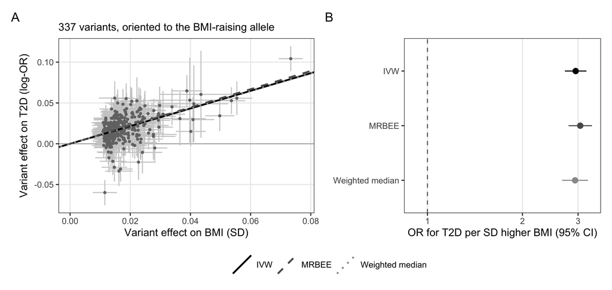

```r
ctl <- res |>
  filter(exposure == "bmi_ukb", outcome == "t2d_xue", arm == "raw", method %in% names(uv_methods)) |>
  mutate(method_label = factor(uv_methods[method], levels = uv_methods))
ctl_snps <- inst |>
  filter(assoc_id == "bmi_ukb__t2d_xue__raw") |>
  mutate(flip = if_else(beta_exposure < 0, -1, 1),
         beta_exposure = beta_exposure * flip, beta_outcome = beta_outcome * flip)
save_source(ctl |> select(exposure, outcome, arm, method, b, se, ci_lo, ci_hi, p, n_snp), "estimates")
save_source(ctl_snps |> select(SNP, beta_exposure, se_exposure, beta_outcome, se_outcome), "variants")

p_sc <- ggplot(ctl_snps, aes(beta_exposure, beta_outcome)) +
  geom_hline(yintercept = 0, colour = "grey70") +
  geom_errorbar(aes(ymin = beta_outcome - 1.96 * se_outcome, ymax = beta_outcome + 1.96 * se_outcome),
                colour = "grey80", width = 0) +
  geom_errorbar(aes(xmin = beta_exposure - 1.96 * se_exposure, xmax = beta_exposure + 1.96 * se_exposure),
                colour = "grey80", width = 0, orientation = "y") +
  geom_point(colour = "grey45", size = 0.8) +
  geom_abline(data = ctl, aes(slope = b, intercept = 0, colour = method_label, linetype = method_label), linewidth = 0.8) +
  scale_colour_manual(values = method_cols) + scale_linetype_manual(values = method_lty) +
  expand_limits(x = 0) +
  labs(x = "Variant effect on BMI (SD)", y = "Variant effect on T2D (log-OR)", colour = NULL, linetype = NULL,
       subtitle = sprintf("%d variants, oriented to the BMI-raising allele", nrow(ctl_snps))) +
  theme_ms + theme(panel.grid.major.y = element_line())
p_fo <- ggplot(ctl, aes(x = exp(b), xmin = exp(ci_lo), xmax = exp(ci_hi), y = forcats::fct_rev(method_label),
                        colour = method_label)) +
  geom_vline(xintercept = 1, linetype = "dashed", colour = "grey40") +
  geom_pointrange(size = 0.4) +
  scale_x_log10(limits = c(0.9, NA)) +
  scale_colour_manual(values = method_cols, guide = "none") +
  labs(x = "OR for T2D per SD higher BMI (95% CI)", y = NULL) +
  theme_ms
p_sc + p_fo + plot_layout(widths = c(1.3, 1), guides = "collect") + plot_annotation(tag_levels = "A") &
  theme(legend.position = "bottom")
```

### Instrument strength

R² for type 2 diabetes is converted from the observed case/control scale to the liability scale (Lee et al. 2011). **The case/control counts and the 10% prevalence are unconfirmed** (Open items). F is scale-free.

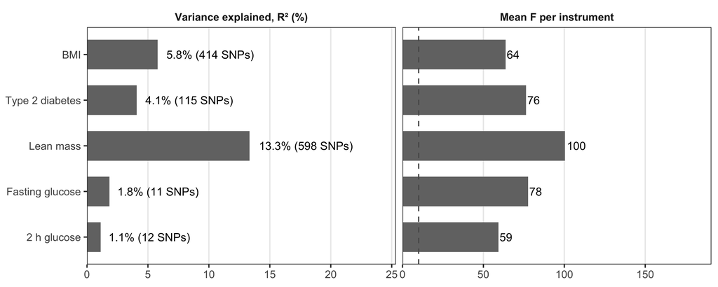

```r
binary_exposures <- tibble::tibble(exposure = "t2d_xue", n_case = 62892, n_control = 596424, prevalence = 0.10)
liability_factor <- function(K, P) {
  z <- dnorm(qnorm(1 - K))
  K^2 * (1 - K)^2 / (z^2 * P * (1 - P))
}
strength_exposures <- unique(c("bmi_ukb", body_exposures, glyc_exposures))
strength <- res |>
  filter(exposure %in% strength_exposures, outcome == ad_outcome, arm == "raw", method == "IVW-MRE") |>
  left_join(binary_exposures, by = "exposure") |>
  mutate(R2_observed = R2,
         R2 = R2 * coalesce(liability_factor(prevalence, n_case / (n_case + n_control)), 1)) |>
  transmute(exposure, exposure_label = factor(short[exposure], levels = rev(short[strength_exposures])),
            n_snp, R2_pct = 100 * R2, R2_observed_pct = 100 * R2_observed, mean_F, total_F, N_exposure,
            binary = !is.na(prevalence))
save_source(strength)

strength |>
  pivot_longer(c(R2_pct, mean_F), names_to = "metric") |>
  mutate(metric = factor(c(R2_pct = "Variance explained, R² (%)", mean_F = "Mean F per instrument")[metric],
                         levels = c("Variance explained, R² (%)", "Mean F per instrument")),
         label = if_else(metric == "Mean F per instrument", sprintf("%.0f", value),
                         sprintf("%.1f%% (%d SNPs)", value, n_snp))) |>
  ggplot(aes(value, exposure_label)) +
  geom_col(fill = "grey45", width = 0.65) +
  geom_vline(data = data.frame(metric = factor("Mean F per instrument"), x = 10),
             aes(xintercept = x), linetype = "dashed", colour = dark) +
  geom_text(aes(label = label), hjust = -0.1, size = 3) +
  facet_wrap(~ metric, scales = "free_x") +
  scale_x_continuous(expand = expansion(mult = c(0, 0.9))) +
  labs(x = NULL, y = NULL) +
  theme_ms
```

```r
strength |>
  arrange(desc(exposure_label)) |>
  transmute(Exposure = exposure_label, SNPs = n_snp, `GWAS N` = N_exposure, `R² (%)` = round(R2_pct, 2),
            `R² observed scale (%)` = if_else(binary, as.character(round(R2_observed_pct, 2)), "—"),
            `Mean F` = round(mean_F, 1), `Overall F` = round(total_F, 1)) |>
  save_table("instrument_strength_univariable")
```

[output not shown]

```r
step0 |>
  transmute(Set = set, SNPs = n_snp, `Mean F, fasting` = round(mean_F_fg, 1), `Mean F, 2 h` = round(mean_F_2h, 1),
            `Conditional F, fasting | 2 h` = round(cond_F_fg, 1), `Conditional F, 2 h | fasting` = round(cond_F_2h, 1),
            `Error correlation (fasting, 2 h)` = round(error_cor_fg_2h, 3), `Pre-specified analysis` = primary_analysis) |>
  save_table("instrument_strength_fg_2h", "Step 0 (outcome-blind). Conditional F < 10 for 2 h glucose in every set, so the contrast regression is primary.")
```

Step 0 (outcome-blind). Conditional F < 10 for 2 h glucose in every set, so the contrast regression is primary.

| Set | SNPs | Mean F, fasting | Mean F, 2 h | Conditional F, fasting \| 2 h | Conditional F, 2 h \| fasting | Error correlation (fasting, 2 h) | Pre-specified analysis |
| --- | --- | --- | --- | --- | --- | --- | --- |
| primary | 299 | 22.3 | 5.0 | 11.1 | 4.0 | 0.111 | contrast regression |
| all_t2d | 445 | 15.6 | 3.6 | 8.2 | 3.0 | 0.111 | contrast regression |
| fg_unadjusted | 117 | 2.7 | 6.7 | 1.7 | 2.8 | 0.041 | contrast regression |
| xue | 115 | 46.8 | 7.7 | 14.2 | 5.6 | 0.111 | contrast regression |
| xue_dupuis | 88 | 4.9 | 8.4 | 1.8 | 2.3 | 0.041 | contrast regression |

### Concordance across every method

Direction and whether the 95% interval excludes zero: the only comparison valid across scales (MR-APSS, CAUSE and MRAID are SD per SD; the rest are log-OR per unit). Blank cells were not run.

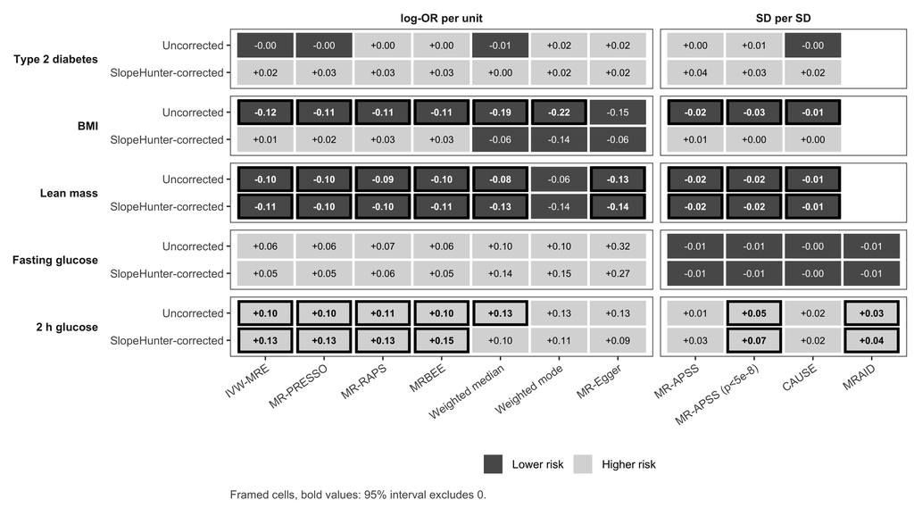

```r
grid_methods <- c("IVW-MRE", "MR-PRESSO", "MR-RAPS", "MRBEE", "Weighted median", "Weighted mode",
                  "MR-Egger", "MR-APSS", "MR-APSS (p<5e-8)", "CAUSE", "MRAID")
grid_exposures <- unique(c(body_exposures, glyc_exposures))
calls <- c("Lower risk, interval excludes 0", "Lower risk, n.s.", "Higher risk, n.s.", "Higher risk, interval excludes 0")
conc <- res |>
  filter(exposure %in% grid_exposures, outcome == ad_outcome, method %in% grid_methods) |>
  mutate(excl = ci_lo * ci_hi > 0,
         call = factor(case_when(b < 0 & excl ~ calls[1], b < 0 ~ calls[2],
                                 b >= 0 & !excl ~ calls[3], TRUE ~ calls[4]), levels = calls),
         method = factor(method, levels = grid_methods),
         family = if_else(grepl("^SD", scale), "SD per SD", "log-OR per unit"),
         arm_label = factor(arm_labels[arm], levels = rev(arm_labels)),
         exposure_label = factor(short[exposure], levels = short[grid_exposures]))
save_source(conc |> select(exposure, outcome, arm, method, scale, b, ci_lo, ci_hi, p, call))

# Greyscale: fill = direction; a black frame and bold text = interval excludes 0.
conc <- conc |> mutate(direction = factor(if_else(b < 0, "Lower risk", "Higher risk"),
                                          levels = c("Lower risk", "Higher risk")))
ggplot(conc, aes(method, arm_label, fill = direction)) +
  geom_tile(colour = "white", linewidth = 0.8) +
  geom_tile(data = filter(conc, excl), fill = NA, colour = "black", linewidth = 0.9, width = 0.9, height = 0.85) +
  geom_text(aes(label = sprintf("%+.2f", b), colour = direction, fontface = if_else(excl, "bold", "plain")),
            size = 2.4, show.legend = FALSE) +
  facet_grid(exposure_label ~ family, scales = "free_x", space = "free_x", switch = "y") +
  scale_fill_manual(values = c(`Lower risk` = "grey35", `Higher risk` = "grey85"), drop = FALSE) +
  scale_colour_manual(values = c(`Lower risk` = "white", `Higher risk` = "black")) +
  labs(x = NULL, y = NULL, fill = NULL, caption = "Framed cells, bold values: 95% interval excludes 0.") +
  theme_ms +
  theme(axis.text.x = element_text(angle = 35, hjust = 1), strip.placement = "outside",
        strip.text.y.left = element_text(angle = 0, hjust = 1), panel.grid = element_blank())
```

## Supplementary: combined Uffelmann (all cohorts)

The most precise AD file, but it contains most of Bellenguez’s cohorts, so it adds precision, not independent evidence. Uncorrected: SlopeHunter is not identified for it.

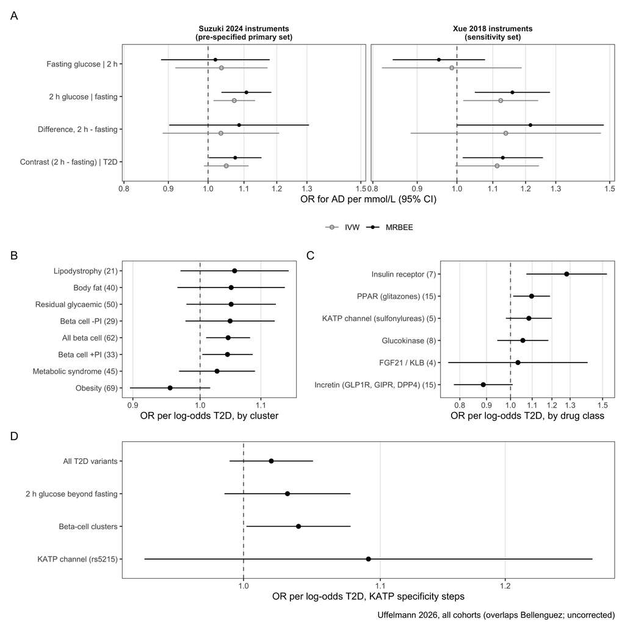

```r
pa <- con |>
  filter(set %in% names(set_labels), outcome == comb_out, arm == comb_arm, scale == "per mmol/L",
         estimator %in% names(con_methods), term %in% names(term_labels)) |>
  mutate(set_label = factor(set_labels[set], levels = set_labels),
         term_label = factor(term_labels[term], levels = rev(term_labels)),
         method_label = factor(con_methods[estimator], levels = con_methods))
pb <- cl_pick(con_cl) |>
  filter(outcome == comb_out, arm == comb_arm, !group %in% c("other (small)", "Liver/lipid metabolism")) |>
  mutate(label = factor(sprintf("%s (%d)", group, n_snp)))
pb <- pb |> mutate(label = forcats::fct_reorder(label, b))
pc <- dt |> filter(outcome == comb_out, arm == comb_arm, trait == "AD (log-OR)", n_snp >= 3) |>
  mutate(label = forcats::fct_reorder(sprintf("%s (%d)", class, n_snp), b))
pd <- spec |> filter(outcome == comb_out) |> mutate(label = factor(step, levels = rev(spec_steps)))
save_source(pa |> select(set, step, estimator, term, b, se, p, n_snp), "fg-2h")
save_source(pb |> select(group, b, se, p, n_snp), "clusters")
save_source(pc |> select(target, class, b, se, p, n_snp), "drug-targets")
save_source(pd |> select(step, b, se, p, n_snp), "katp-specificity")

or_breaks <- c(0.7, 0.8, 0.9, 1, 1.1, 1.2, 1.3, 1.5, 1.75, 2)   # log-scale defaults drop the ticks above 1
simple_forest <- function(d, xlab, colour = ink) {
  ggplot(d, aes(x = exp(b), xmin = exp(b - 1.96 * se), xmax = exp(b + 1.96 * se), y = label)) +
    geom_vline(xintercept = 1, linetype = "dashed", colour = "grey40") +
    geom_pointrange(colour = colour, size = 0.3) +
    scale_x_log10(breaks = or_breaks) + labs(x = xlab, y = NULL) + theme_ms
}
fa <- ggplot(pa, aes(x = exp(b), xmin = exp(b - 1.96 * se), xmax = exp(b + 1.96 * se), y = term_label,
                     colour = method_label, shape = method_label)) +
  geom_vline(xintercept = 1, linetype = "dashed", colour = "grey40") +
  geom_pointrange(position = position_dodge(width = 0.5), size = 0.3) +
  facet_wrap(~ set_label, labeller = label_wrap_gen(30)) +
  scale_x_log10(breaks = or_breaks) + scale_colour_manual(values = con_cols) + scale_shape_manual(values = con_shapes) +
  labs(x = "OR for AD per mmol/L (95% CI)", y = NULL, colour = NULL, shape = NULL) + theme_ms
fa / (simple_forest(pb, "OR per log-odds T2D, by cluster") | simple_forest(pc, "OR per log-odds T2D, by drug class")) /
  simple_forest(pd, "OR per log-odds T2D, KATP specificity steps") +
  plot_annotation(tag_levels = "A", caption = comb_lab)
```

## Figures made by other notebooks

These figures are not redrawn here. Each notebook records its own inputs, and the README maps them to figure numbers.

| Content | Notebook | File |
| --- | --- | --- |
| Causal diagrams (study design, survival collider) | `mr_dags.qmd` | `figures/dags-*-1.pdf` |
| SlopeHunter mechanism (A–D) | `slopehunter_figure.qmd` | `figures/supp-slopehunter-mechanism.pdf` |
| SlopeHunter sensitivity to b | `slopehunter_figure.qmd` | `figures/supp-slopehunter-sensitivity.pdf` |
| MVMR with lifespan (cross-check) | `mvmr_lifespan_indexevent.qmd` | `mvmr_lifespan_indexevent_files/figure-html/forest-1.png` (PNG only; no `fig.path`) |
| KCNJ11/ABCC8 fine-mapping | `diabetes_ad_fine_mapping.qmd` | `figures/finemap-*-1.pdf` (reads the local `_targets` store on every render) |

## Open items

Values that feed into reported numbers and are marked unconfirmed at their source. Resolve these before the numbers go into the text.

| Value | Where | Used by |
| --- | --- | --- |
| `sd_mmol: {fg: 0.65, glu2h: 1.85}`, “TO CONFIRM from the MAGIC cohorts” | `pipeline/config.yml` → `contrast:` | every **per-SD** contrast, cluster-contrast and MVMR estimate (not the per-mmol/L figures here) |
| T2D cases 62,892 / controls 596,424, prevalence 10% (“VERIFY”) | the `instrument-strength` chunk above | liability-scale R² for T2D |
| Suzuki 2024 cohort list (“TO CONFIRM against Supplementary Table 1”) | `config.yml` → `t2d_suzuki_eur` | sample-overlap statements (MVP in both Suzuki and the Uffelmann new cohorts) |
| Uffelmann clinical-only cohort list (“TO CONFIRM”) | `config.yml` → `ad_uffelmann_cc` | overlap with Bellenguez |
| Suzuki sumstats MD5 does not match the DIAGRAM page | `config.yml` → `t2d_suzuki_eur` comment | which file version the instruments came from |
| `fg_chen` p-value source (“TO CHECK”: raw-mmol/L beta with INT p?) | `config.yml` → `fg_chen` | instrument selection on fasting glucose (Chen) |
| Fat-free mass covariates (“to confirm”) | `config.yml` → `ffm_ukb` | data-sources table |

## Session

```r
writeLines(c(sprintf("Rendered %s at commit %s", Sys.time(), head_commit), capture.output(print(si))),
           file.path(ms_dir, "session_info.txt"))
si
```